# Wrangling Shark Attack Data: Species & Activity

Fisher

April 13, 2016

```r
# Load the data
dat <- read_csv("Shark_Attack_Data_4-7-2016.csv",col_names=TRUE,n_max=5897) #5897=last good row
dat[24] <- NULL #remove null rows and repeated Case Number rows
dat[23] <- NULL
dat[21] <- NULL
dat[20] <- NULL
```

```r
# Working with Windows to Unicode special characters...

#dat %>% filter(grepl("(Bay, near Charleston)",Location)) %>% select(Location) %>% #View()
#  mutate(Location=iconv(Location,from="CP1252",to="UTF-8")) %>% View()
#  #filter(grepl("([’])",Location)) %>% View()
#dat %>% filter(grepl("(Bay, near Charleston)",Location)) %>% select(Location) %>%
#  mutate(Location=stri_escape_unicode(iconv(Location,from="CP1252",to="UTF-8"))) %>%
#  #mutate(Location=gsub("’","",Location,perl=TRUE)) %>% View()
#  mutate(Location=gsub("(\\\\u2019)","'",Location,perl=TRUE)) %>% View()
```

## Wrangle the Species column

The Species variable provides textual descriptions of the species of shark reported in the shark attack. The descriptions are free form. In addition to possibly including the **type of shark**, many entries include its **size** (length and/or weight range), **gender**, and other miscellaneous information. Therefore, the Species variable needs to be wrangled, or normalized, so that the shark types can be parsed and extracted. As the additional information contained in a Species entry may be useful for downstream processing and analysis, it is also wrangled and used to create additional variables, e.g., length, weight, and gender.

Note, only 3001 of 5897 reported incidents contain information about the shark species.

#### Normalize the Species descriptions

General normalization…

```r
## Normalize all Species column entries

dat2 <- dat %>% filter(!is.na(Species)) %>%
  mutate(Species=iconv(Species,from="CP1252",to="UTF-8"),
         Species=stri_trans_tolower(Species)) %>%
  select(`Case Number`,Species) # Lowercase all Species text

dat2 <- dat2 %>% filter(!is.na(Species)) %>%
  mutate(Species=gsub("([0-9]{1,2}\\/[0-9]{1,2}\\/[0-9]{4})"," ",Species))
# Remove annoying unicode characters
dat2 <- dat2 %>% filter(!is.na(Species)) %>%
  mutate(Species=gsub("(\u393C|\u3E33|\u613C|\u3E30|\u3E34|\u623C|\u3E64|\uFFFD)","",Species))

## Remove all double quotes at the beginning and end of each Species entry
dat2 <- dat2 %>% filter(!is.na(Species)) %>%
  mutate(Species=gsub(pattern="(^|[\\s])[\"]"," ",Species), #from beginning  “
         #Species=gsub(pattern="([^0-9])([\"])([\\S]|$)","\\1",Species)) #ending (unless preceded by a digit)
         Species=gsub(pattern="([\"])([a-z -]+)([\"])","\\2",Species),
         Species=gsub(pattern="([a-z -]+)([\"])","\\1",Species))

dat2 <- dat2 %>% filter(!is.na(Species)) %>% #Remove unnecessary punctuation
  mutate(Species=gsub(pattern="([a-zA-Z])[\\.]","\\1 ",Species), #removes word-final periods
         Species=gsub(pattern="\\?+"," ",Species), #removes question marks
         Species=gsub(pattern="[,;:]"," ",Species), #removes commas & semicolons
         Species=gsub(pattern="\\[|\\]"," ",Species), #removes square brackets
         Species=gsub(pattern="\\(|\\)"," ",Species)) #, #remove parentheses
         #Species=gsub(pattern="([e])[\"][\\s]","\\1 ",Species)) #strange double quote won't go away.


dat2 <- dat2 %>% filter(!is.na(Species)) %>% #normalize shark length descriptions
  mutate(Species=gsub(pattern="pound","lb",Species), #pound to lb
    Species=gsub(pattern="(\\d)(\\s|-)(metre|m|meter|cm|ft|feet|foot|kg|lb|lbs)(\\s|$)","\\1\\3 ",Species),
         Species=gsub(pattern="(\\d)(?-)(ft|feet|foot)(\\s|$)","\\1' ",Species),
         Species=gsub(pattern="(\\d)(?-)(meter|metre)(\\s|$)","\\1m ",Species))

dat2 <- dat2 %>% filter(!is.na(Species)) %>%
  mutate(Species=gsub(pattern="(\\w)(\\s|-)(tipped)(\\s|$|\")","\\1tip ",Species), #normalizes tipped to tip
         Species=gsub(pattern="(sharks|shar k|shar ;)","shark",Species), # normalize 'shark'
         Species=gsub(pattern="( shar)\\s+([^k])"," shark \\2",Species), # normalize 'shark'

         Species=gsub(pattern="(\\d)(')(shark)","\\1\\2 \\3",Species), #5'shark to 5' shark
         Species=gsub(pattern=" (\")(\\w)"," \\2",Species), #turns "word into word
         Species=gsub(pattern="(fragment|wobbegong|day|pointer)(s)","\\1",Species), #plural to singular
         Species=gsub(pattern=" & "," and ",Species), # & to and
         Species=gsub(pattern="zambezi","zambesi",Species), #zambesi
         Species=gsub(pattern="grey","gray",Species), #gray
         Species=gsub(pattern="(seven gill|seven-gill|7-gill)","sevengill",Species), # sevengill
         Species=gsub(pattern="(sandtiger|sand-tiger)","sand tiger",Species), # sand tiger
         Species=gsub(pattern="([\\s]nose|-nosed|[\\s]nosed)","nose",Species)) # broadnose, ..nose

dat2 <- dat2 %>% filter(!is.na(Species)) %>%
  mutate(Species=gsub(pattern="catshark","cat shark",Species))

dat2 <- dat2 %>% filter(!is.na(Species)) %>%
  mutate(Species=gsub("(not confirmed|not cofirmed)","unconfirmed",Species))

dat2 <- dat2 %>% filter(!is.na(Species)) %>%
  mutate(Species=gsub("(not authenticated)","unauthenticated",Species))


#Remove stop words from entries
#dat2 <- dat2 %>% filter(!is.na(Species)) %>%
#  mutate(Species=gsub("(^|\\s)(another|been|a|as|an|by|of|or|on|that|his|but|it|its|their|than|from|have|out|were|be|is|was|later|on|with|and|the|')($|\\s)"," ",Species))
dat2 <- dat2 %>% filter(!is.na(Species)) %>%
  mutate(Species=gsub("(^|\\s)(another|been|a|as|an|by|of|or|on|that|his|but|it|its|their|than|from|have|out|were|be|is|was|later|on|with|and|the)($|\\s)"," ",Species))

dat2 <- dat2 %>% filter(!is.na(Species)) %>%
  mutate(Species=gsub(pattern="\\s+"," ",Species)) #Reduce multiple spaces to 1 space

#dat2 %>% filter(!is.na(Species)) %>% select(Species) %>% View()
#dat2$Species[675]
```

The following word clouds illustrate the textual information contained in the Species column.

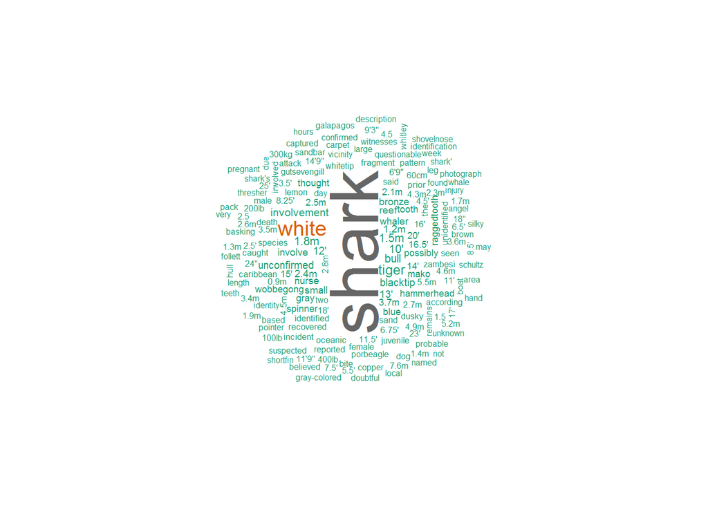

```
## Leaving out the most frequent word 'shark'...
```

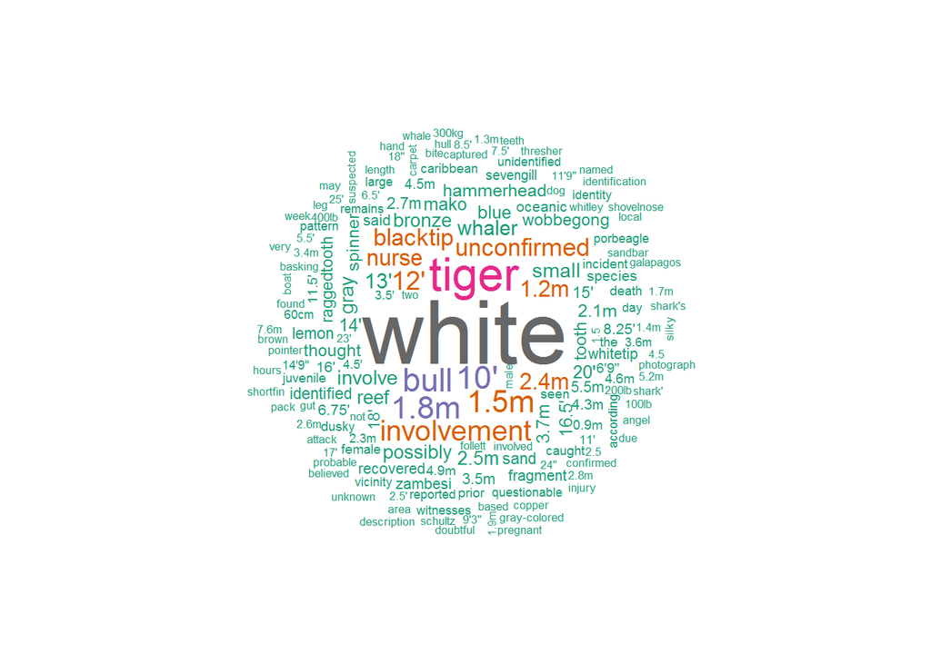

As illustrated, further wrangling is needed. The word clouds show a variety of information that is not in itself categorically coherent.

## Extracting from the Species Column

After exploring, normalizing, analyzing, and visualizing the species entry descriptions, the next step is to extract the three categories. Let’s extract the Species descriptions into three distinct categories: (1) Shark Type, describing the type of shark; (2) Size, describing the size of the shark; and (3) Gender.

#### Shark Type (aka Species)

Here, we’ll add a new column (variable) containing textual descriptions of the species of shark in an attack. This will be cross-correlated with the Shark Species data set.

```r
# sharky words..

#shark_type_pattern <- "(zygena|zygaena|albimarginatus|bamboo|blackfin|blacktip|blue|blue fin|bluefin|bluenose|nose|bonito|bonnethed|bronze|brown|brown-colored|bull|canicula|carcharhinid|carcharhinus|carchar[^\\s]+|caribbean|cat |catshark|cocktail|copper|cow|dog|dusky|francisci|galapagensis|galapagos|galap[^\\s]+|galeolamna|gangeticus|gray|ground|guitarfish|gummy|hammerhead|heterodontus|hooked shot|horn|lemon|leopard|leucas|long thin brown-colored|longfin|loxodon|maculipinnis|mako|nurse|obscurus|oceanic|perezi|porbeagle|raggedtooth|reef|rhizoprionodon|salmon|sand|sandbar|scalloped|scyliorhinus|sevengill|shark|shortfin|shovelnose|silky|silvertip|sixgill|smooth|soupfin|spinner|spotted|spurdog|tawney|tawny|thresher|tintorera|tintorero|whaler|white|whitetip|whtietip|wobbegong|zambesi)"

shark_type_terms <- c("zygena", "zygaena", "albimarginatus", "bamboo", "blackfin", "blacktip", "blue", "blue fin", "bluefin", "bluenose", "nose", "bonito", "bonnethed", "bronze", "brown", "brown-colored", "bull", "canicula", "carcharinid", "carcharhinid", "carcharhinus", "caribbean", "cat ", "catshark", "cocktail", "copper", "cow", "dog  ", "dusky", "francisci", "galapagensis", "galapagos", "galap[^\\s]+|galeolamna", "gangeticus", "gray", "ground", "guitarfish", "gummy", "hammerhead", "heterodontus", "hooked shot", "horn", "lemon", "leopard", "leucas", "long thin brown-colored", "longfin", "loxodon", "maculipinnis", "mako", "nurse", "obscurus", "oceanic", "perezi", "pointer","porbeagle", "raggedtooth", "reef", "rhizoprionodon", "salmon", "sand", "sandbar", "scalloped", "scyliorhinus", "sevengill", "shark", "shortfin", "shovelnose", "silky", "silvertip", "sixgill", "smooth", "soupfin", "spinner", "spotted", "spurdog", "tawney", "tawny", "thresher", "tiger","tintorera", "tintorero", "whaler", "white", "whitetip", "whtietip", "wobbegong", "zambesi", "no shark")

# Remove non-descriptive words..
removeNonTypeWords <- function(s){
  s <- gsub("(^| )(involvement|unconfirmed|description|allegedly|identified|recovered|according|inflicted|reported|diameter|fragment|probable|incident|benjamin|believed|juvenile|possibly|alleged|buttery|present|several|speared|thought|species|involve|remains|bitten|female|attack|caused|killed|little|injury|likely|after|bites|clyde|small|large|dried|cold|post|the|aka|cm|dr|in|kg|lb|to|m|\\/|[a-z0-9\\.]|[\\.\\d\'\"]+|[\\d][\\.]?[\\dmc]{1,2})( |$)"," ",s, perl = TRUE)
  #removed authenticated
  s <- gsub("( to )","",s,perl=TRUE)
  s <- gsub("[^a-z ]+"," ",s,perl=TRUE)
  s <- gsub("( nosed )"," nose ",s, perl = TRUE)
  s <- ifelse(grepl("(leucas)",s, perl = TRUE),"bull shark",s)
  s <- ifelse(grepl("(hoax| not |no shark)",s, perl = TRUE),"no shark",s)
  s <- gsub("whtietip","whitetip",s, perl = TRUE)
  s <- gsub("tawny","tawney",s, perl = TRUE)

  s <- gsub("[\\s]+"," ",s, perl = TRUE)
  (str_trim(s))
}

restrictToSharkTerms <- function(s){

  if(s=="no shark"){
    return(s)
  }

  tokens <- as.list(str_split(s," ")[[1]])
  tokens <- tokens[which(tokens%in%shark_type_terms)]
  s <- str_trim(paste0(tokens,collapse=" "))
  if(nchar(s)>0){
    return(s)
  }
  return(NA)
}

shark_types <- dat2 %>% filter(!is.na(Species)) %>%
  mutate(shark_type=removeNonTypeWords(Species),
         shark_type=sapply(shark_type,FUN=restrictToSharkTerms),
         shark_type=gsub("^(shark )","",shark_type),
         shark_type=gsub("albimarginatus","silvertip shark",shark_type),
         shark_type=gsub("gangeticus","ganges",shark_type),
         shark_type=ifelse(grepl("(shark)",shark_type),shark_type,paste(shark_type," shark",sep=""))
         )

#write.csv(shark_types,file = "shark_types_2.csv",row.names = FALSE)

all_shark_type_text <- shark_types %>% mutate(shark_type=gsub("shark","",shark_type)) %>%
  select(shark_type)
all_shark_type_tokens <- str_split(paste(unlist(all_shark_type_text),collapse=" ")," ")
all_shark_type_terms <- as.data.frame(table(term=all_shark_type_tokens))[-1,] %>% filter(!is.na(term)|term!="NA")

all_shark_type_terms %>% arrange(desc(Freq)) %>% kable
```

| term | Freq |
| --- | --- |
| white | 609 |
| tiger | 280 |
| bull | 173 |
| blacktip | 102 |
| nurse | 90 |
| whaler | 76 |
| reef | 68 |
| bronze | 67 |
| gray | 67 |
| blue | 57 |
| mako | 54 |
| hammerhead | 49 |
| spinner | 47 |
| raggedtooth | 44 |
| wobbegong | 44 |
| sand | 39 |
| NA | 38 |
| lemon | 36 |
| zambesi | 35 |
| whitetip | 32 |
| no | 26 |
| oceanic | 25 |
| sevengill | 20 |
| dusky | 19 |
| caribbean | 17 |
| porbeagle | 10 |
| sandbar | 8 |
| pointer | 7 |
| brown | 6 |
| copper | 6 |
| thresher | 6 |
| galapagos | 4 |
| shortfin | 4 |
| shovelnose | 4 |
| silky | 4 |
| leopard | 3 |
| nose | 3 |
| obscurus | 3 |
| salmon | 3 |
| silvertip | 3 |
| blackfin | 2 |
| canicula | 2 |
| guitarfish | 2 |
| scyliorhinus | 2 |
| spotted | 2 |
| tawney | 2 |
| bamboo | 1 |
| bluenose | 1 |
| bonito | 1 |
| bonnethed | 1 |
| carcharhinid | 1 |
| carcharhinus | 1 |
| carcharinid | 1 |
| cocktail | 1 |
| cow | 1 |
| francisci | 1 |
| galapagensis | 1 |
| ganges | 1 |
| ground | 1 |
| gummy | 1 |
| heterodontus | 1 |
| horn | 1 |
| longfin | 1 |
| loxodon | 1 |
| maculipinnis | 1 |
| perezi | 1 |
| rhizoprionodon | 1 |
| scalloped | 1 |
| sixgill | 1 |
| soupfin | 1 |
| spurdog | 1 |
| tintorero | 1 |
| zygena | 1 |

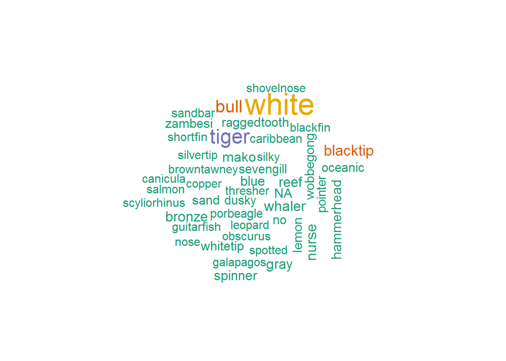

```r
wordcloud(all_shark_type_terms$term,all_shark_type_terms$Freq,
            min.freq = 2,c(2.5,1),
            #random.order=FALSE,
            colors=brewer.pal(6, "Dark2"))
```

#### Shark Size

```r
feet_pattern <- c("([\\d\\.]+)(\')")
inches_pattern <- c("([\\d\\.]+)(\")")
meters_pattern <- c("([\\d\\.]+)(m)")
cm_pattern <- c("([\\d\\.]+)(cm)")
kg_pattern <- c("([\\d\\.]+)(kg)")
lb_pattern <- c("([\\d\\.]+)(lb)")

size_dat <- dat2 %>%
  mutate(feet=as.numeric(gsub("\'","",stri_extract_last_regex(Species,feet_pattern))),
         inches=as.numeric(gsub("\"","",stri_extract_last_regex(Species,inches_pattern))),
         meters=as.numeric(gsub("m","",stri_extract_last_regex(Species,meters_pattern))),
         cm=as.numeric(gsub("cm","",stri_extract_last_regex(Species,cm_pattern))),
         kg=as.numeric(gsub("kg","",stri_extract_last_regex(Species,kg_pattern))),
         lb=as.numeric(gsub("lb","",stri_extract_last_regex(Species,lb_pattern)))
  )

size_dat <- size_dat %>%
  mutate(feet=ifelse(!is.na(feet)&!is.na(inches),
                       feet+(inches/12), # combine feet+inches into feet
                     ifelse(is.na(feet)&!is.na(inches),
                            inches/12,feet)),
         meters=ifelse(is.na(meters)&!is.na(feet),feet*0.3048, # 1ft = 0.3048m
                       ifelse(!is.na(cm),cm/100,meters)),
         kg=ifelse(is.na(kg)&!is.na(lb),lb*0.453592,kg) # lb to kg ~ 1 to 0.453592

  ) %>% select(-inches,-cm,-lb)

#write.csv(size_dat,"shark_size.csv",row.names = FALSE,quote=FALSE)

summary(size_dat$meters) #%>% kable(caption='Length Summary (meters)')
```

```
##    Min. 1st Qu.  Median    Mean 3rd Qu.    Max.    NA's
##  0.2032  1.5240  2.4000  2.7120  3.6580 10.0600    1088
```

```r
summary(size_dat$kg) #%>% kable(caption='Weight Summary (kg)')
```

```
##     Min.  1st Qu.   Median     Mean  3rd Qu.     Max.     NA's
##    3.629   79.690  140.000  239.800  274.600 3500.000     2886
```

#### Shark Gender

```r
gender_dat <- dat2 %>%
  mutate(Species=gsub("(pregnant)","female",Species),
         gender=ifelse(grepl("(female)",Species),
                       "female",
                       ifelse(grepl("male",Species),
                              "male",
                              NA))
         ) %>% filter(!is.na(gender))



#write.csv(gender_dat,"shark_gender.csv",row.names = FALSE,quote=FALSE)
gender_dat %>% group_by(gender) %>% summarize(n=n())
```

```
## Source: local data frame [2 x 2]
##
##   gender     n
##    (chr) (int)
## 1 female    22
## 2   male     8
```

## Wrangle the Activity column

```r
#Wrangle the activity column..

#names(dat)[names(dat)=="Case Number"] <- "CaseNumber"

activity_dat <- dat %>% select(`Case Number`,Activity) %>% filter(!is.na(Activity))

activity_dat <- activity_dat %>%
  mutate(Activity=iconv(Activity,from="CP1252",to="UTF-8"),
         Activity=stri_trans_tolower(Activity)) # Lowercase all Activity text

# Remove annoying unicode characters
activity_dat <- activity_dat %>%
  mutate(Activity=gsub("(\u393C|\u3E33|\u613C|\u3E30|\u3E34|\u623C|\u3E64|\uFFFD)","",Activity))

activity_dat <- activity_dat %>% mutate(Activity=str_trim(gsub("[\\s\"'`\\?\\(\\),;:-]+"," ",Activity,perl=TRUE))) #%>% View()
#activity_dat$Activity <- stringr::str_replace_all(activity$Activity,"[\\s\"'`\\?\\(\\)]+", " ")

activity_dat %>% group_by(Activity) %>% summarize(freq=n()) %>% arrange(desc(freq)) %>% head(20)
```

```
## Source: local data frame [20 x 2]
##
##           Activity  freq
##              (chr) (int)
## 1          surfing   882
## 2         swimming   850
## 3          fishing   422
## 4     spearfishing   320
## 5          bathing   155
## 6           wading   141
## 7           diving   125
## 8         standing    98
## 9     scuba diving    80
## 10      snorkeling    75
## 11   body boarding    61
## 12    body surfing    49
## 13 boogie boarding    43
## 14    pearl diving    32
## 15  treading water    32
## 16     free diving    29
## 17        kayaking    29
## 18     surf skiing    29
## 19  fell overboard    22
## 20     windsurfing    18
```

```r
activity_dat %>% filter(grepl("ing( |$)",Activity)) %>%
  group_by(Activity) %>% summarize(freq=n()) %>% arrange(desc(freq)) %>% head(20)
```

```
## Source: local data frame [20 x 2]
##
##           Activity  freq
##              (chr) (int)
## 1          surfing   882
## 2         swimming   850
## 3          fishing   422
## 4     spearfishing   320
## 5          bathing   155
## 6           wading   141
## 7           diving   125
## 8         standing    98
## 9     scuba diving    80
## 10      snorkeling    75
## 11   body boarding    61
## 12    body surfing    49
## 13 boogie boarding    43
## 14    pearl diving    32
## 15  treading water    32
## 16     free diving    29
## 17        kayaking    29
## 18     surf skiing    29
## 19     windsurfing    18
## 20   shark fishing    16
```

```r
# How deep?
activity_dat %>% filter(grepl("deep",Activity)) %>%
  mutate(depth=str_extract(Activity,"([^\\s]+[\\s]){2}(deep|depth)")) %>%
  group_by(depth) %>% summarize(freq=n()) %>% arrange(desc(freq)) %>% head(20)
```

```
## Source: local data frame [11 x 2]
##
##               depth  freq
##               (chr) (int)
## 1     in waist deep    10
## 2      in knee deep     9
## 3     in chest deep     4
## 4        0.9 m deep     3
## 5     in ankle deep     2
## 6     her into deep     1
## 7       him to deep     1
## 8       in hip deep     1
## 9  in shoulder deep     1
## 10  shark into deep     1
## 11               NA     1
```

```r
activity_tokens <- unlist(str_split(activity_dat$Activity," "))
num_tok <- length(activity_tokens)
num_uniq <- length(unique(activity_tokens))
act_word_counts <- as.data.frame(table(term=activity_tokens))

act_stop_words <- c("another", "been", "a", "as", "an", "by", "of", "or", "on", "that", "his", "but", "it", "its", "their", "than", "from", "have", "out", "were", "be", "is", "was", "later", "on", "with", "and", "the")

act_word_counts %>% filter(!term%in%act_stop_words) %>% head(20)
```

```
##           term Freq
## 1                1
## 2            &  177
## 3            .    5
## 4            /   78
## 5       shark    1
## 6  swallowed    1
## 7          0.9    3
## 8          000    5
## 9        04h00    1
## 10          05    1
## 11       09h57    1
## 12           1    3
## 13          10    5
## 14  10/24/1944    3
## 15         100    4
## 16          11    4
## 17   11/6/1988    2
## 18          12    3
## 19         124    1
## 20         125    1
```

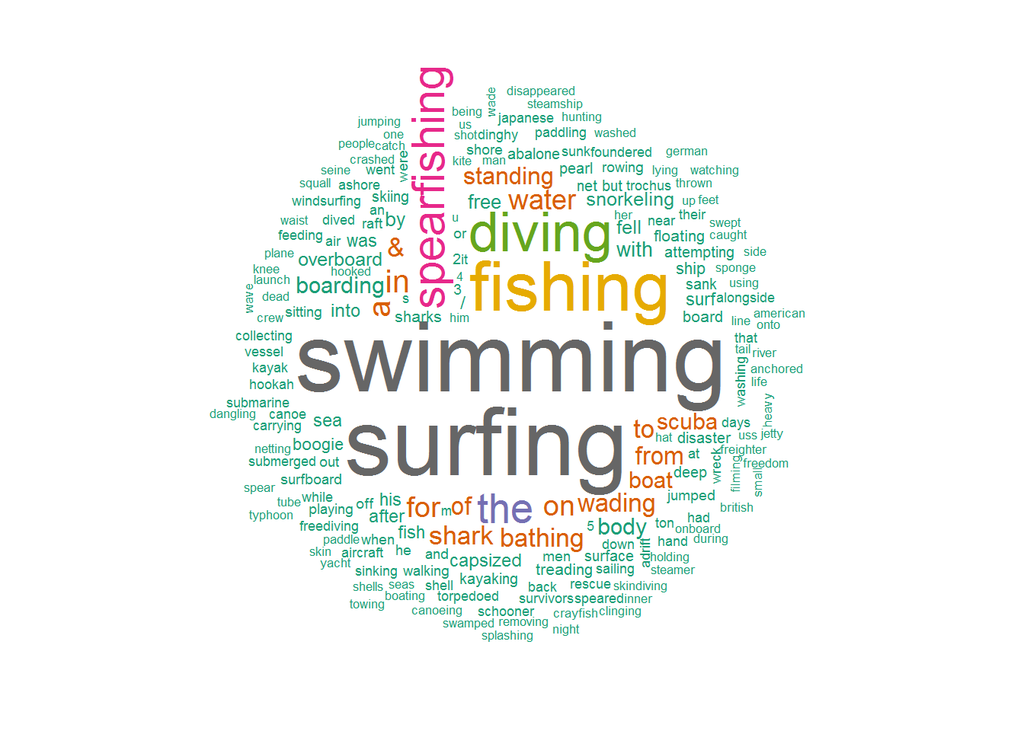

```r
wordcloud(act_word_counts$term,act_word_counts$Freq,
          min.freq = 8,
          random.order=FALSE,
          colors=brewer.pal(8, "Dark2"))
```